# Intro to igraph

March 10, 2018

## Why Graph - Data schema is the actual data model

## Why Graph - Graph databases scale really well

## Why Graph - Recommendation Systems

## Why Graph - Recommendation Systems Continued

## Why Graph - Recommendation Systems Continued Again

## Terminology - Undirected Graph

- **A**, **B**, and **C** are nodes/vertices
- **1** and **2** are edges/links

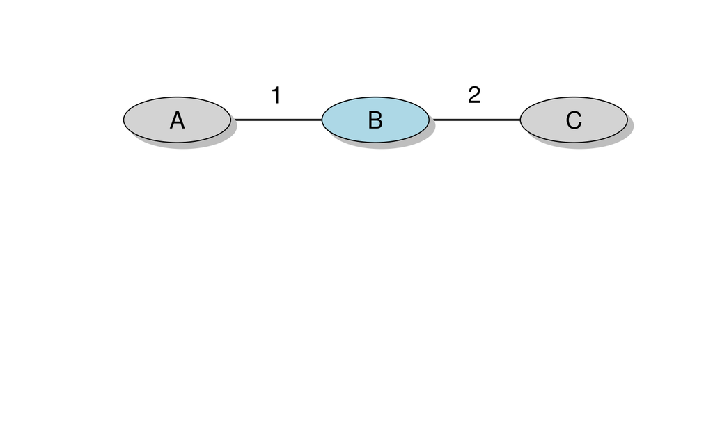

## Terminology - Directed Graph

- **A**, **B**, and **C** are nodes/vertices
- **1** and **2** are edges/links
- Edge **1** is coming **IN** to node **B**
- Edge **2** is going **OUT** of node **B**
- Node **B** is at the **HEAD** of edge **1**
- Node **B** is at the **TAIL** of edge **2**

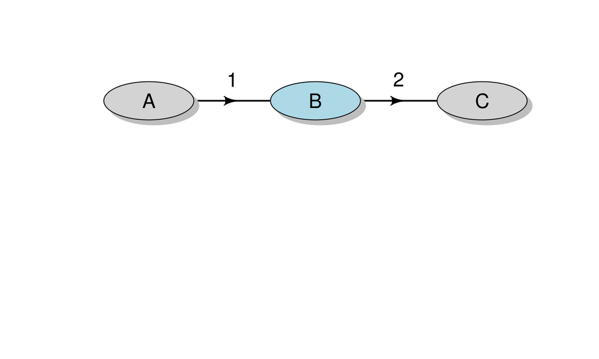

## Terminology - Simple Graph - unweighted - undirected - no loops - no multiple edges

## Terminology - Multigraph

- None of the previous restrictions

## Terminology Continued

- A **walk** is a sequence of vertices and edges
- A **path** is a walk with no repeating vertices with the possible exception of the first and final vertices.

## Creating graphs from scratch

1. `make_empty_graph()`: Initialize and empty graph to build on
2. `vertices()`: Create the vertices/nodes of the graph
3. `edges()`: Create the edges/links connecting the vertices

## Create an undirected graph from scratch

```r
library(igraph)

g_undirected <- make_empty_graph(directed = F) +
  vertices(c('a', 'b', 'c', 'd', 'e'),
           type = "letters",
           order = 1, 2, 3, 4, 5) +
  edges(c('a', 'b',
          'b', 'c',
          'b', 'd',
          'c', 'e'),
        type = "connection",
        weight = c(1, 1, 2, 2))
```

## Information from undirected graph

```r
g_undirected
```

```
## IGRAPH 690f754 UNWB 9 4 --
## + attr: name (v/c), type (v/c), order (v/n), type (e/c), weight
## | (e/n)
## + edges from 690f754 (vertex names):
## [1] a--b b--c b--d c--e
```

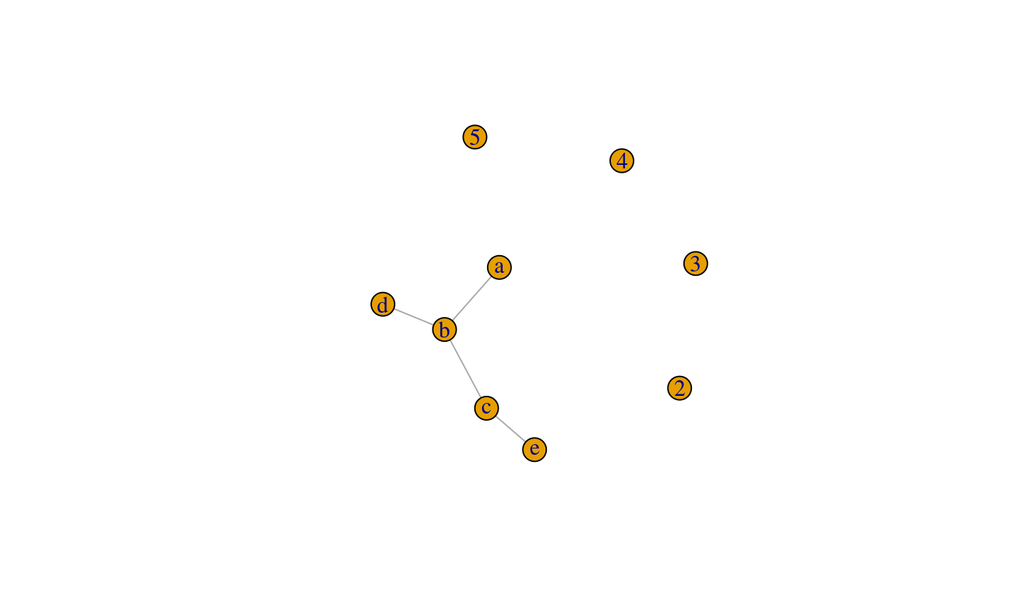

## Create a directed graph from scratch

```r
g_directed <- make_empty_graph(directed = T) +
  vertices(c('a', 'b', 'c', 'd', 'e'),
           type = "letter",
           order = c(1, 2, 3, 4, 5)) +
  edges(c('a', 'b',
          'b', 'c',
          'b', 'd',
          'c', 'e'),
        type = "connection",
        weight = c(1, 1, 2, 2))
```

## Information from directed graph

```r
g_directed
```

```
## IGRAPH 7e234d2 DNWB 5 4 --
## + attr: name (v/c), type (v/c), order (v/n), type (e/c), weight
## | (e/n)
## + edges from 7e234d2 (vertex names):
## [1] a->b b->c b->d c->e
```

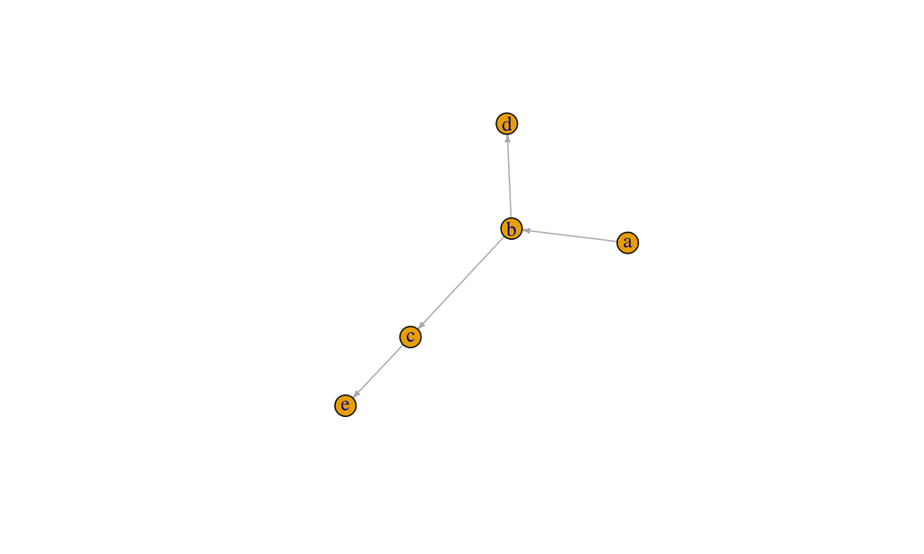

## Creating graphs from data frames

1. Create and edge list that represents the links of the graph
   - OPTIONAL: Create a node list with information about each unique node
2. `graph_from_data_frame()`: Creates a graph from the edge list

## Creating a graph from a data frame

```r
node_list <- data.frame(
  name = c('a', 'b', 'c', 'd', 'e'),
  type = "letter",
  order = c(1, 2, 3, 4, 5)
)
edges(c('a', 'b',
          'b', 'c',
          'b', 'd',
          'c', 'e'),
        type = "connection",
        weight = c(1, 1, 2, 2))
```

```
## [[1]]
## [1] "a" "b" "b" "c" "b" "d" "c" "e"
##
## $type
## [1] "connection"
##
## $weight
## [1] 1 1 2 2
##
## attr(,"class")
## [1] "igraph.edge"
```

```r
edge_list <- data.frame(
  source = c('a', 'b', 'b', 'c'),
  target = c('b', 'c', 'd', 'e'),
  type = 'connection',
  weight = c(1, 1, 2, 2)
)
g <- graph_from_data_frame(d = edge_list,
                           directed = T,
                           vertices = node_list)
```

## Information from directed graph

```r
g
```

```
## IGRAPH 1dec0e9 DNWB 5 4 --
## + attr: name (v/c), type (v/c), order (v/n), type (e/c), weight
## | (e/n)
## + edges from 1dec0e9 (vertex names):
## [1] a->b b->c b->d c->e
```

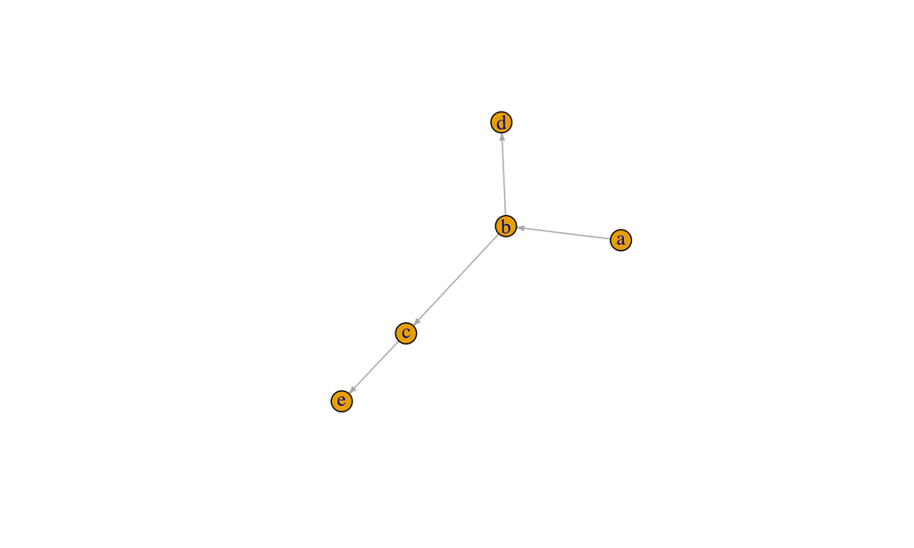

## Accessing/Manipulating Data from graph

given graph **g**

- `V(g)`: provides a vector of all vertices/nodes of a graph
- `E(g)`: provides a vector of all edges/links of a graph
- `vcount(g)`: provides the number of vertices/nodes of a graph
- `ecount(g)`: provides the number of edges/links of a graph
- `vertex_attr_names(g)`: provides the names of all the attributes stored in vertices/nodes
- `edge_attr_names(g)`: provides the names of all the attributes stored in edges/links

## V()

Vertices can be accessed by their **id**. If the graph is a named graph, then the **name** also functions as an id.

```r
V(g)
```

```
## + 5/5 vertices, named, from 1dec0e9:
## [1] a b c d e
```

```r
V(g)[3]
```

```
## + 1/5 vertex, named, from 1dec0e9:
## [1] c
```

```r
V(g)['c']
```

```
## + 1/5 vertex, named, from 1dec0e9:
## [1] c
```

## V() Continued

Accessing a vertex using double square bracket notation gives you all the information of the vertex.

```r
V(g)[['c']]
```

```
## + 1/5 vertex, named, from 1dec0e9:
##   name   type order
## 3    c letter     3
```

```r
V(g)[['c']]$order
```

```
## [1] 3
```

```r
V(g)['c']$order <- 29
V(g)[['c']]
```

```
## + 1/5 vertex, named, from 1dec0e9:
##   name   type order
## 3    c letter    29
```

## V() Continued Again

You can access multiple vertices either by providing a vector of names or ids or by **querying the attributes** of the vertex vector.

```r
V(g)[[c('a', 'e')]]
```

```
## + 2/5 vertices, named, from 1dec0e9:
##   name   type order
## 1    a letter     1
## 5    e letter     5
```

```r
V(g)[[order >= 4]]
```

```
## + 3/5 vertices, named, from 1dec0e9:
##   name   type order
## 3    c letter    29
## 4    d letter     4
## 5    e letter     5
```

## E()

Edges can have names and can be accessed directly using either a name or an id, however, as graphs get larger, the sheer number and variety of edges make it very impractical to do so.

```r
E(g)
```

```
## + 4/4 edges from 1dec0e9 (vertex names):
## [1] a->b b->c b->d c->e
```

```r
E(g)[1]
```

```
## + 1/4 edge from 1dec0e9 (vertex names):
## [1] a->b
```

```r
E(g)[[1]]
```

```
## + 1/4 edge from 1dec0e9 (vertex names):
##   tail head tid hid       type weight
## 1    a    b   1   2 connection      1
```

## E() Continued

Instead edges should be accessed by querying their attributes

```r
E(g)[weight == 2]
```

```
## + 2/4 edges from 1dec0e9 (vertex names):
## [1] b->d c->e
```

```r
E(g)[[weight == 2]]
```

```
## + 2/4 edges from 1dec0e9 (vertex names):
##   tail head tid hid       type weight
## 3    b    d   2   4 connection      2
## 4    c    e   3   5 connection      2
```

```r
E(g)[[weight == 2]][1]$weight <- -20000
E(g)[[weight <= 0]]
```

```
## + 1/4 edge from 1dec0e9 (vertex names):
##   tail head tid hid       type weight
## 3    b    d   2   4 connection -20000
```

## E() Continued Again

We can also **query edges for the nodes they connect.**

```r
E(g)['a' %--% 'b']
```

```
## + 1/4 edge from 1dec0e9 (vertex names):
## [1] a->b
```

```r
E(g)[['c' %<-% 'b']]
```

```
## + 1/4 edge from 1dec0e9 (vertex names):
##   tail head tid hid       type weight
## 2    b    c   2   3 connection      1
```

```r
E(g)[['b' %->% V(g)]]
```

```
## + 2/4 edges from 1dec0e9 (vertex names):
##   tail head tid hid       type weight
## 2    b    c   2   3 connection      1
## 3    b    d   2   4 connection -20000
```

## Subgraphs

Sometimes you may only want to work with a part of the entire graph.

- `induced_subgraph()`: creates a subgraph that includes only the vertices provided and keeps all the edges between those vertices.
- `subgraph.edges()`: creates a subgraph that includes only the edges provided and keeps all the vertices they connect to. Unconnected vertices can also be kept if `delete.vertices = F`

```r
abc_sub <- induced_subgraph(g, c('a', 'b', 'c'))
abc_sub
```

```
## IGRAPH 2516f57 DNWB 3 2 --
## + attr: name (v/c), type (v/c), order (v/n), type (e/c), weight
## | (e/n)
## + edges from 2516f57 (vertex names):
## [1] a->b b->c
```

```r
b_sub <- subgraph.edges(g, E(g)["b" %--% V(g)])
b_sub
```

```
## IGRAPH 00c8c3f DNWB 4 3 --
## + attr: name (v/c), type (v/c), order (v/n), type (e/c), weight
## | (e/n)
## + edges from 00c8c3f (vertex names):
## [1] a->b b->c b->d
```

## Subgraphs Gotchas

In igraph, subgraphs are completely new graphs and their components are completely different from those of the graphs they were created from. The below won't work:

```r
E(g)["b" %--% V(b_sub)]
```

Instead, you will need to use attributes that you know are in both graphs, like names:

```r
E(g)["b" %--% V(b_sub)$name]
```

```
## + 3/4 edges from 1dec0e9 (vertex names):
## [1] a->b b->c b->d
```

## Random Graph Generation - Erdos Renyi Game

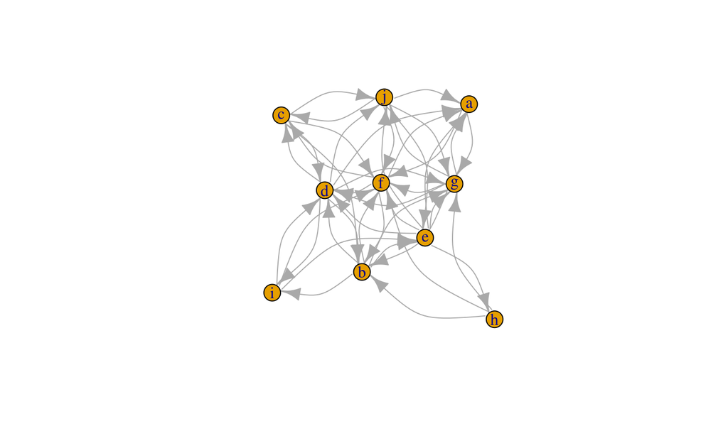

```r
set.seed(1234)
g <- erdos.renyi.game(10, .5, directed = T)
V(g)$name <- letters[1:10]
V(g)$randomValue <- runif(vcount(g), 0, 100)
E(g)$randomWeight1 <- runif(ecount(g), 0, 100)
E(g)$randomWeight2 <- runif(ecount(g), 0, 100)
plot(g,
     edge.curved = T)
```

## Degree

```r
degree(g) %>%
  sort(T)
```

```
##  d  f  g  b  e  j  a  c  i  h
## 12 12 11 10  9  9  7  7  5  4
```

```r
degree(g, mode = 'in') %>%
  sort(T)
```

```
## f d g a b j c e i h
## 8 6 6 5 5 4 3 3 2 1
```

```r
degree(g, c('b', 'e')) %>%
  sort(T)
```

```
##  b  e
## 10  9
```

## Strength - Weighted Degree

```r
strength(g, mode = 'out', weights = E(g)$randomWeight1)
```

```
##         a         b         c         d         e         f         g
##  80.66157 177.20435 252.33482 378.75271 366.96583 182.66195 316.37588
##         h         i         j
## 113.35033 153.71472 368.42219
```

```r
strength(g, mode = 'in', weights = E(g)$randomWeight1)
```

```
##         a         b         c         d         e         f         g
## 331.10687 331.16721 172.60650 314.68181 183.52996 331.56839 292.45237
##         h         i         j
##  42.69758 110.26927 280.36442
```

```r
strength(g, c('b', 'e'), mode = 'in', weights = E(g)$randomWeight1)
```

```
##        b        e
## 331.1672 183.5300
```

## Betweeness

```r
betweenness(g) %>%
  sort(T)
```

```
##          b          e          d          f          g          j
## 11.5952381 10.3095238  9.4047619  9.2023810  7.5357143  4.8333333
##          c          i          a          h
##  1.5357143  0.8333333  0.5000000  0.2500000
```

```r
page_rank(g)$vector %>%
  sort(T)
```

```
##          f          d          g          b          a          c
## 0.17299034 0.13819469 0.13570872 0.11951643 0.11813963 0.08581189
##          j          e          i          h
## 0.08514035 0.06534534 0.05489537 0.02425726
```

```r
eigen_centrality(g, directed = T)$vector %>%
  sort(T)
```

```
##         f         d         a         g         b         j         c
## 1.0000000 0.8816919 0.8339691 0.8054750 0.7570186 0.5989487 0.5624970
##         e         i         h
## 0.3917307 0.3715854 0.0888268
```

## Ego

The ego or neighborhood of a vertex V is a vector of vertices that are within a given order or V:

```r
ego(g, order = 1, nodes = 'b', mode = 'all')
```

```
## [[1]]
## + 8/10 vertices, named, from 95fc2f6:
## [1] b c d e f g h i
```

```r
ego(g, order = 2, nodes = c('b', 'e'), mode = 'in')
```

```
## [[1]]
## + 10/10 vertices, named, from 95fc2f6:
##  [1] b c d f g h j e i a
##
## [[2]]
## + 9/10 vertices, named, from 95fc2f6:
## [1] e b i j c d f g h
```

## Shortest Paths

```r
shortest_paths(g, 'h', 'c', mode = 'out', output = 'both', weight = E(g)$randomWeight1)$epath[[1]] %>% .[[1:length(.)]]
```

```
## + 3/43 edges from 95fc2f6 (vertex names):
##    tail head tid hid randomWeight1 randomWeight2
## 31    h    f   8   6      22.48458      30.76657
## 19    f    d   6   4      22.85997      81.00834
## 12    d    c   4   3      35.69871      63.24424
```

```r
shortest_paths(g, 'h', 'c', mode = 'out', output = 'both', weight = E(g)$randomWeight2)$epath[[1]] %>% .[[1:length(.)]]
```

```
## + 2/43 edges from 95fc2f6 (vertex names):
##    tail head tid hid randomWeight1 randomWeight2
## 31    h    f   8   6      22.48458      30.76657
## 13    f    c   6   3      62.74777      31.00942
```

## Combo

```r
gt75_nodes <- V(g)[[randomValue >= 75]]
gt75_ego <- ego(g, 1, gt75_nodes, 'in')
gt75_ego
```

```
## [[1]]
## + 6/10 vertices, named, from 95fc2f6:
## [1] a d e f g j
##
## [[2]]
## + 2/10 vertices, named, from 95fc2f6:
## [1] h e
```

## Combo Continued

```r
unlist(gt75_ego)
```

```
##  a  d  e  f  g  j  h  e
##  1  4  5  6  7 10  8  5
```

```r
names_gt75 <- names(unlist(gt75_ego))

induced_subgraph(g, names_gt75)
```

```
## IGRAPH 1e87496 DN-- 7 23 -- Erdos renyi (gnp) graph
## + attr: name (g/c), type (g/c), loops (g/l), p (g/n), name (v/c),
## | randomValue (v/n), randomWeight1 (e/n), randomWeight2 (e/n)
## + edges from 1e87496 (vertex names):
##  [1] d->a e->a f->a g->a j->a d->j e->d f->d g->d e->j j->e a->f e->f g->f
## [15] h->f j->f a->g d->g e->g g->j h->g j->g e->h
```

## Pulling edges of interest

```r
E(g)[randomWeight1 >= 90]
```

```
## + 6/43 edges from 95fc2f6 (vertex names):
## [1] e->a g->a g->b c->d e->j j->e
```

```r
E(g)[randomWeight1 >= 90] %>%
  .['a' %--% V(g)]
```

```
## + 2/43 edges from 95fc2f6 (vertex names):
## [1] e->a g->a
```

## Putting edge info into nodes

```r
V(g)$in_weights <- strength(g, mode = 'in', weights = E(g)$randomWeight1)
V(g)$out_weights <- strength(g, mode = 'out', weights = E(g)$randomWeight1)
V(g)[[1:vcount(g)]]
```

```
## + 10/10 vertices, named, from 95fc2f6:
##    name randomValue in_weights out_weights
## 1     a    94.23607  331.10687    80.66157
## 2     b    48.61354  331.16721   177.20435
## 3     c    28.34595  172.60650   252.33482
## 4     d    25.15457  314.68181   378.75271
## 5     e    50.32552  183.52996   366.96583
## 6     f    49.69662  331.56839   182.66195
## 7     g    31.84458  292.45237   316.37588
## 8     h    96.22228   42.69758   113.35033
## 9     i    63.40994  110.26927   153.71472
## 10    j    12.74334  280.36442   368.42219
```

## Putting node info into edges

```r
E(g)$out_impact <- E(g)$randomWeight1/head_of(g, E(g))$in_weights
E(g)$in_impact <- E(g)$randomWeight1/tail_of(g, E(g))$out_weights
E(g)[[1:10]]
```

```
## + 10/43 edges from 95fc2f6 (vertex names):
##    tail head tid hid randomWeight1 randomWeight2 out_impact in_impact
## 1     d    a   4   1      42.30470     42.403021 0.12776751 0.1116948
## 2     e    a   5   1      91.43169     56.088725 0.27613952 0.2491559
## 3     f    a   6   1      46.77923     11.613577 0.14128137 0.2560973
## 4     g    a   7   1      90.81691     30.302180 0.27428279 0.2870539
## 5     j    a  10   1      59.77433     47.880269 0.18052881 0.1622441
## 6     c    b   3   2      63.17428     34.483055 0.19076249 0.2503590
## 7     d    b   4   2      86.91583     60.071414 0.26245301 0.2294791
## 8     f    b   6   2      50.27498      7.608332 0.15181147 0.2752351
## 9     g    b   7   2      98.36351     95.599261 0.29702068 0.3109071
## 10    h    b   8   2      32.43860      2.220682 0.09795234 0.2861800
```

## magrittr: an aside

```r
rev_n <- function(nodes, func, graph, ...){
  arg <- formals(func) %>%
    names() %>%
    .[sapply(., function(x) grepl('^v|^n', x, T))] %>%
    .[1]

  temp <- list()
  temp[[arg]] <- nodes
  temp[['graph']] <- graph

  temp <- c(temp, as.list(match.call(expand.dots = F)[["..."]]))
  do.call(func, temp)
}
```

## magrittr: another aside

```r
rev_e <- function(edges, func, graph, ...){
  arg <- formals(func) %>%
    names() %>%
    .[sapply(., function(x) grepl('^e', x, T))] %>%
    .[1]

  temp <- list()
  temp[[arg]] <- edges
  temp[['graph']] <- graph

  temp <- c(temp, as.list(match.call(expand.dots = F)[["..."]]))
  do.call(func, temp)
}
```

## USING THE HELPERS

```r
g %>%
  E() %>%
  .[randomWeight1 == max(.$randomWeight1)] %>%
  rev_e(ends, g) %>%
  c() %>%
  rev_n(ego, g, order = 1, 'out') %>%
  unlist() %>%
  rev_n(induced.subgraph, g)
```

```
## IGRAPH 1f139e2 DN-- 8 29 -- Erdos renyi (gnp) graph
## + attr: name (g/c), type (g/c), loops (g/l), p (g/n), name (v/c),
## | randomValue (v/n), in_weights (v/n), out_weights (v/n),
## | randomWeight1 (e/n), randomWeight2 (e/n), out_impact (e/n),
## | in_impact (e/n)
## + edges from 1f139e2 (vertex names):
##  [1] d->a e->a f->a g->a j->a c->j d->c f->c j->c c->d d->j e->d f->d g->d
## [15] e->j j->e a->f c->f e->f g->f h->f j->f a->g d->g e->g g->j h->g j->g
## [29] e->h
```